# Risk Factor Analysis

## Outcome Variable

**Outcome Variable:** stunted

## Predictor Variables

**Intervention Variable:** enstunt

**Adjustment Set:**

- arm
- sex
- W_mage
- meducyrs
- feducyrs
- vagbrth
- single
- brthmon
- W_parity
- impsan
- delta_W_mage
- delta_meducyrs
- delta_feducyrs
- delta_vagbrth
- delta_single
- delta_brthmon
- delta_W_parity
- delta_impsan

## Stratifying Variables

The analysis was stratified on these variable(s):

- agecat
- studyid
- country

## Data Summary

| agecat | studyid | country | enstunt | stunted | n_cell | n |
| --- | --- | --- | --- | --- | --- | --- |
| Birth | ki0047075b-MAL-ED | BANGLADESH | 0 | 0 | 187 | 231 |
| Birth | ki0047075b-MAL-ED | BANGLADESH | 0 | 1 | 0 | 231 |
| Birth | ki0047075b-MAL-ED | BANGLADESH | 1 | 0 | 0 | 231 |
| Birth | ki0047075b-MAL-ED | BANGLADESH | 1 | 1 | 44 | 231 |
| Birth | ki0047075b-MAL-ED | BRAZIL | 0 | 0 | 56 | 65 |
| Birth | ki0047075b-MAL-ED | BRAZIL | 0 | 1 | 0 | 65 |
| Birth | ki0047075b-MAL-ED | BRAZIL | 1 | 0 | 0 | 65 |
| Birth | ki0047075b-MAL-ED | BRAZIL | 1 | 1 | 9 | 65 |
| Birth | ki0047075b-MAL-ED | INDIA | 0 | 0 | 37 | 47 |
| Birth | ki0047075b-MAL-ED | INDIA | 0 | 1 | 0 | 47 |
| Birth | ki0047075b-MAL-ED | INDIA | 1 | 0 | 0 | 47 |
| Birth | ki0047075b-MAL-ED | INDIA | 1 | 1 | 10 | 47 |
| Birth | ki0047075b-MAL-ED | NEPAL | 0 | 0 | 25 | 27 |
| Birth | ki0047075b-MAL-ED | NEPAL | 0 | 1 | 0 | 27 |
| Birth | ki0047075b-MAL-ED | NEPAL | 1 | 0 | 0 | 27 |
| Birth | ki0047075b-MAL-ED | NEPAL | 1 | 1 | 2 | 27 |
| Birth | ki0047075b-MAL-ED | PERU | 0 | 0 | 207 | 233 |
| Birth | ki0047075b-MAL-ED | PERU | 0 | 1 | 0 | 233 |
| Birth | ki0047075b-MAL-ED | PERU | 1 | 0 | 0 | 233 |
| Birth | ki0047075b-MAL-ED | PERU | 1 | 1 | 26 | 233 |
| Birth | ki0047075b-MAL-ED | SOUTH AFRICA | 0 | 0 | 113 | 123 |
| Birth | ki0047075b-MAL-ED | SOUTH AFRICA | 0 | 1 | 0 | 123 |
| Birth | ki0047075b-MAL-ED | SOUTH AFRICA | 1 | 0 | 0 | 123 |
| Birth | ki0047075b-MAL-ED | SOUTH AFRICA | 1 | 1 | 10 | 123 |
| Birth | ki0047075b-MAL-ED | TANZANIA, UNITED REPUBLIC OF | 0 | 0 | 102 | 125 |
| Birth | ki0047075b-MAL-ED | TANZANIA, UNITED REPUBLIC OF | 0 | 1 | 0 | 125 |
| Birth | ki0047075b-MAL-ED | TANZANIA, UNITED REPUBLIC OF | 1 | 0 | 0 | 125 |
| Birth | ki0047075b-MAL-ED | TANZANIA, UNITED REPUBLIC OF | 1 | 1 | 23 | 125 |
| Birth | ki1000108-CMC-V-BCS-2002 | INDIA | 0 | 0 | 75 | 92 |
| Birth | ki1000108-CMC-V-BCS-2002 | INDIA | 0 | 1 | 0 | 92 |

[output cut: 298 more lines]

The following strata were considered:

- agecat: 24 months, studyid: ki0047075b-MAL-ED, country: BANGLADESH
- agecat: 24 months, studyid: ki0047075b-MAL-ED, country: BRAZIL
- agecat: 24 months, studyid: ki0047075b-MAL-ED, country: INDIA
- agecat: 24 months, studyid: ki0047075b-MAL-ED, country: NEPAL
- agecat: 24 months, studyid: ki0047075b-MAL-ED, country: PERU
- agecat: 24 months, studyid: ki0047075b-MAL-ED, country: SOUTH AFRICA
- agecat: 24 months, studyid: ki0047075b-MAL-ED, country: TANZANIA, UNITED REPUBLIC OF
- agecat: 24 months, studyid: ki1000108-CMC-V-BCS-2002, country: INDIA
- agecat: 24 months, studyid: ki1000108-IRC, country: INDIA
- agecat: 24 months, studyid: ki1000109-EE, country: PAKISTAN
- agecat: 24 months, studyid: ki1017093-NIH-Birth, country: BANGLADESH
- agecat: 24 months, studyid: ki1017093b-PROVIDE, country: BANGLADESH
- agecat: 24 months, studyid: ki1017093c-NIH-Crypto, country: BANGLADESH
- agecat: 24 months, studyid: ki1066203-TanzaniaChild2, country: TANZANIA, UNITED REPUBLIC OF
- agecat: 24 months, studyid: ki1101329-Keneba, country: GAMBIA
- agecat: 24 months, studyid: ki1113344-GMS-Nepal, country: NEPAL
- agecat: 24 months, studyid: ki1114097-CMIN, country: BANGLADESH
- agecat: 24 months, studyid: ki1114097-CONTENT, country: PERU
- agecat: 24 months, studyid: ki1119695-PROBIT, country: BELARUS
- agecat: 24 months, studyid: ki1126311-ZVITAMBO, country: ZIMBABWE
- agecat: 24 months, studyid: ki1135781-COHORTS, country: GUATEMALA
- agecat: 24 months, studyid: ki1135781-COHORTS, country: INDIA
- agecat: 24 months, studyid: ki1135781-COHORTS, country: PHILIPPINES
- agecat: 24 months, studyid: ki1148112-LCNI-5, country: MALAWI
- agecat: 24 months, studyid: kiGH5241-JiVitA-3, country: BANGLADESH
- agecat: 24 months, studyid: kiGH5241-JiVitA-4, country: BANGLADESH
- agecat: 6 months, studyid: ki0047075b-MAL-ED, country: BANGLADESH
- agecat: 6 months, studyid: ki0047075b-MAL-ED, country: BRAZIL
- agecat: 6 months, studyid: ki0047075b-MAL-ED, country: INDIA
- agecat: 6 months, studyid: ki0047075b-MAL-ED, country: NEPAL
- agecat: 6 months, studyid: ki0047075b-MAL-ED, country: PERU
- agecat: 6 months, studyid: ki0047075b-MAL-ED, country: SOUTH AFRICA
- agecat: 6 months, studyid: ki0047075b-MAL-ED, country: TANZANIA, UNITED REPUBLIC OF
- agecat: 6 months, studyid: ki1000108-CMC-V-BCS-2002, country: INDIA
- agecat: 6 months, studyid: ki1000108-IRC, country: INDIA
- agecat: 6 months, studyid: ki1000109-EE, country: PAKISTAN
- agecat: 6 months, studyid: ki1000109-ResPak, country: PAKISTAN
- agecat: 6 months, studyid: ki1000304b-SAS-CompFeed, country: INDIA
- agecat: 6 months, studyid: ki1000304b-SAS-FoodSuppl, country: INDIA
- agecat: 6 months, studyid: ki1017093-NIH-Birth, country: BANGLADESH
- agecat: 6 months, studyid: ki1017093b-PROVIDE, country: BANGLADESH
- agecat: 6 months, studyid: ki1017093c-NIH-Crypto, country: BANGLADESH
- agecat: 6 months, studyid: ki1066203-TanzaniaChild2, country: TANZANIA, UNITED REPUBLIC OF
- agecat: 6 months, studyid: ki1101329-Keneba, country: GAMBIA
- agecat: 6 months, studyid: ki1112895-Guatemala BSC, country: GUATEMALA
- agecat: 6 months, studyid: ki1113344-GMS-Nepal, country: NEPAL
- agecat: 6 months, studyid: ki1114097-CMIN, country: BANGLADESH
- agecat: 6 months, studyid: ki1114097-CONTENT, country: PERU
- agecat: 6 months, studyid: ki1119695-PROBIT, country: BELARUS
- agecat: 6 months, studyid: ki1126311-ZVITAMBO, country: ZIMBABWE
- agecat: 6 months, studyid: ki1135781-COHORTS, country: GUATEMALA
- agecat: 6 months, studyid: ki1135781-COHORTS, country: INDIA
- agecat: 6 months, studyid: ki1135781-COHORTS, country: PHILIPPINES
- agecat: 6 months, studyid: ki1148112-LCNI-5, country: MALAWI
- agecat: 6 months, studyid: kiGH5241-JiVitA-3, country: BANGLADESH
- agecat: 6 months, studyid: kiGH5241-JiVitA-4, country: BANGLADESH
- agecat: Birth, studyid: ki0047075b-MAL-ED, country: BANGLADESH
- agecat: Birth, studyid: ki0047075b-MAL-ED, country: BRAZIL
- agecat: Birth, studyid: ki0047075b-MAL-ED, country: INDIA
- agecat: Birth, studyid: ki0047075b-MAL-ED, country: NEPAL
- agecat: Birth, studyid: ki0047075b-MAL-ED, country: PERU
- agecat: Birth, studyid: ki0047075b-MAL-ED, country: SOUTH AFRICA
- agecat: Birth, studyid: ki0047075b-MAL-ED, country: TANZANIA, UNITED REPUBLIC OF
- agecat: Birth, studyid: ki1000108-CMC-V-BCS-2002, country: INDIA
- agecat: Birth, studyid: ki1000108-IRC, country: INDIA
- agecat: Birth, studyid: ki1000109-EE, country: PAKISTAN
- agecat: Birth, studyid: ki1000109-ResPak, country: PAKISTAN
- agecat: Birth, studyid: ki1000304b-SAS-CompFeed, country: INDIA
- agecat: Birth, studyid: ki1017093-NIH-Birth, country: BANGLADESH
- agecat: Birth, studyid: ki1017093b-PROVIDE, country: BANGLADESH
- agecat: Birth, studyid: ki1017093c-NIH-Crypto, country: BANGLADESH
- agecat: Birth, studyid: ki1101329-Keneba, country: GAMBIA
- agecat: Birth, studyid: ki1113344-GMS-Nepal, country: NEPAL
- agecat: Birth, studyid: ki1114097-CMIN, country: BANGLADESH
- agecat: Birth, studyid: ki1114097-CONTENT, country: PERU
- agecat: Birth, studyid: ki1119695-PROBIT, country: BELARUS
- agecat: Birth, studyid: ki1126311-ZVITAMBO, country: ZIMBABWE
- agecat: Birth, studyid: ki1135781-COHORTS, country: GUATEMALA
- agecat: Birth, studyid: ki1135781-COHORTS, country: INDIA
- agecat: Birth, studyid: ki1135781-COHORTS, country: PHILIPPINES
- agecat: Birth, studyid: kiGH5241-JiVitA-3, country: BANGLADESH
- agecat: Birth, studyid: kiGH5241-JiVitA-4, country: BANGLADESH

### Dropped Strata

Some strata were dropped due to rare outcomes:

- agecat: Birth, studyid: ki0047075b-MAL-ED, country: BANGLADESH
- agecat: Birth, studyid: ki0047075b-MAL-ED, country: BRAZIL
- agecat: Birth, studyid: ki0047075b-MAL-ED, country: INDIA
- agecat: Birth, studyid: ki0047075b-MAL-ED, country: NEPAL
- agecat: Birth, studyid: ki0047075b-MAL-ED, country: PERU
- agecat: Birth, studyid: ki0047075b-MAL-ED, country: SOUTH AFRICA
- agecat: Birth, studyid: ki0047075b-MAL-ED, country: TANZANIA, UNITED REPUBLIC OF
- agecat: Birth, studyid: ki1000108-CMC-V-BCS-2002, country: INDIA
- agecat: Birth, studyid: ki1000108-IRC, country: INDIA
- agecat: Birth, studyid: ki1000109-EE, country: PAKISTAN
- agecat: Birth, studyid: ki1000109-ResPak, country: PAKISTAN
- agecat: Birth, studyid: ki1000304b-SAS-CompFeed, country: INDIA
- agecat: Birth, studyid: ki1017093-NIH-Birth, country: BANGLADESH
- agecat: Birth, studyid: ki1017093b-PROVIDE, country: BANGLADESH
- agecat: Birth, studyid: ki1017093c-NIH-Crypto, country: BANGLADESH
- agecat: Birth, studyid: ki1101329-Keneba, country: GAMBIA
- agecat: Birth, studyid: ki1113344-GMS-Nepal, country: NEPAL
- agecat: Birth, studyid: ki1114097-CMIN, country: BANGLADESH
- agecat: Birth, studyid: ki1114097-CONTENT, country: PERU
- agecat: Birth, studyid: ki1119695-PROBIT, country: BELARUS
- agecat: Birth, studyid: ki1126311-ZVITAMBO, country: ZIMBABWE
- agecat: Birth, studyid: ki1135781-COHORTS, country: GUATEMALA
- agecat: Birth, studyid: ki1135781-COHORTS, country: INDIA
- agecat: Birth, studyid: ki1135781-COHORTS, country: PHILIPPINES
- agecat: Birth, studyid: kiGH5241-JiVitA-3, country: BANGLADESH
- agecat: Birth, studyid: kiGH5241-JiVitA-4, country: BANGLADESH
- agecat: 6 months, studyid: ki0047075b-MAL-ED, country: BRAZIL
- agecat: 6 months, studyid: ki0047075b-MAL-ED, country: NEPAL
- agecat: 6 months, studyid: ki1148112-LCNI-5, country: MALAWI
- agecat: 24 months, studyid: ki0047075b-MAL-ED, country: BRAZIL
- agecat: 24 months, studyid: ki0047075b-MAL-ED, country: TANZANIA, UNITED REPUBLIC OF
- agecat: 24 months, studyid: ki1066203-TanzaniaChild2, country: TANZANIA, UNITED REPUBLIC OF
- agecat: 24 months, studyid: ki1119695-PROBIT, country: BELARUS

## Methods Detail

We’re interested in the causal parameters $E[Y_a]$ for all values of $a \in \mathcal{A}$. These parameters represent the mean outcome if, possibly contrary to fact, we intervened to set all units to have $A=a$. Under the randomization and positivity assumptions, these are identified by the statistical parameters $\psi_a=E_W[E_{Y|A,W}(Y|A=a,W)]$. In addition, we’re interested in the mean of $Y$, $E[Y]$ under no intervention (the observed mean). We will estimate these parameters by using SuperLearner to fit the relevant likelihood factors – $E_{Y|A,W}(Y|A=a,W)$ and $p(A=a|W)$, and then updating our likelihood fit using a joint TMLE.

For unadjusted analyses ($W=\{\}$), initial likelihoods were estimated using Lrnr_glm to estimate the simple $E(Y|A)$ and Lrnr_mean to estimate $p(A)$. For adjusted analyses, a small library containing Lrnr_glmnet, Lrnr_xgboost, and Lrnr_mean was used.

Having estimated these parameters, we will then use the delta method to estimate relative risks and attributable risks relative to a prespecified baseline level of $A$.

# Results Detail

## Results Plots

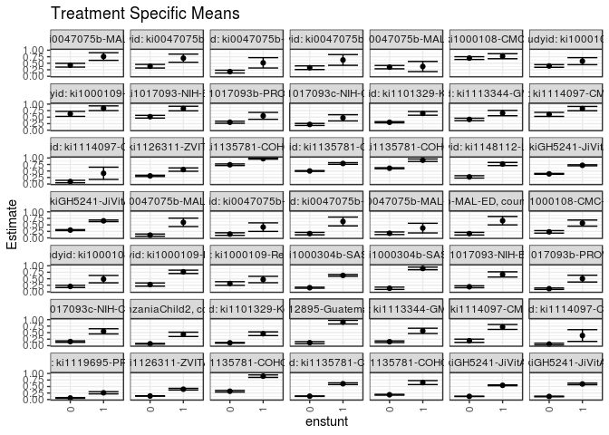

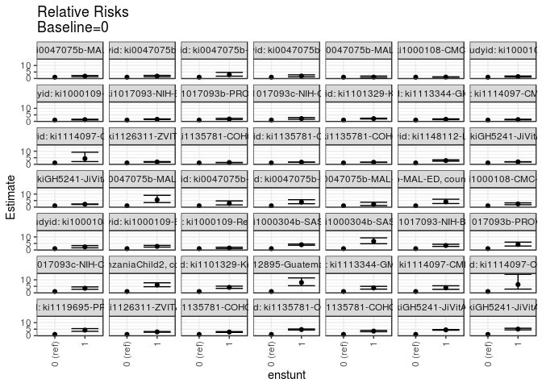

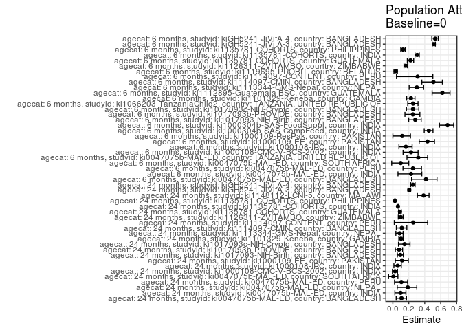

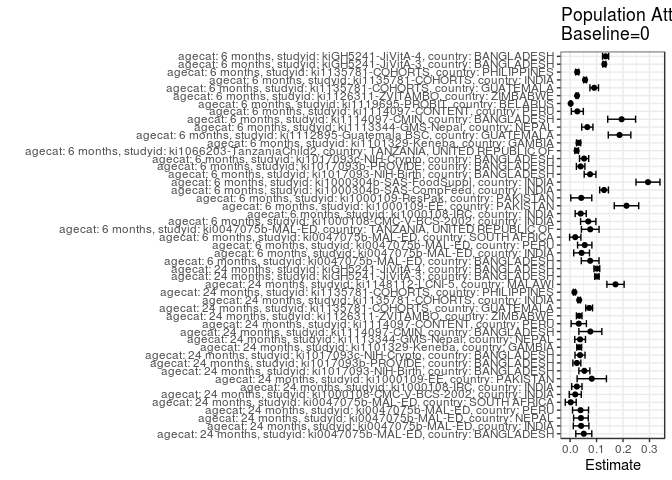

## Results Table

### Parameter: TSM

| agecat | studyid | country | intervention_level | baseline_level | estimate | ci_lower | ci_upper |
| --- | --- | --- | --- | --- | --- | --- | --- |
| 6 months | ki0047075b-MAL-ED | BANGLADESH | 0 | NA | 0.1066612 | 0.0640931 | 0.1492293 |
| 6 months | ki0047075b-MAL-ED | BANGLADESH | 1 | NA | 0.5973484 | 0.4361981 | 0.7584986 |
| 6 months | ki0047075b-MAL-ED | INDIA | 0 | NA | 0.1471341 | 0.0975294 | 0.1967388 |
| 6 months | ki0047075b-MAL-ED | INDIA | 1 | NA | 0.4136045 | 0.2488283 | 0.5783807 |
| 6 months | ki0047075b-MAL-ED | PERU | 0 | NA | 0.1643681 | 0.1174548 | 0.2112813 |
| 6 months | ki0047075b-MAL-ED | PERU | 1 | NA | 0.6304484 | 0.4609684 | 0.7999284 |
| 6 months | ki0047075b-MAL-ED | SOUTH AFRICA | 0 | NA | 0.1773221 | 0.1275154 | 0.2271288 |
| 6 months | ki0047075b-MAL-ED | SOUTH AFRICA | 1 | NA | 0.3762929 | 0.1902810 | 0.5623048 |
| 6 months | ki0047075b-MAL-ED | TANZANIA, UNITED REPUBLIC OF | 0 | NA | 0.1626775 | 0.1123971 | 0.2129579 |
| 6 months | ki0047075b-MAL-ED | TANZANIA, UNITED REPUBLIC OF | 1 | NA | 0.6605183 | 0.4984544 | 0.8225823 |
| 6 months | ki1000108-CMC-V-BCS-2002 | INDIA | 0 | NA | 0.2321349 | 0.1835631 | 0.2807067 |
| 6 months | ki1000108-CMC-V-BCS-2002 | INDIA | 1 | NA | 0.5684924 | 0.4515752 | 0.6854096 |
| 6 months | ki1000108-IRC | INDIA | 0 | NA | 0.2055277 | 0.1634940 | 0.2475614 |
| 6 months | ki1000108-IRC | INDIA | 1 | NA | 0.4852217 | 0.3440207 | 0.6264227 |
| 6 months | ki1000109-EE | PAKISTAN | 0 | NA | 0.2774789 | 0.2164335 | 0.3385242 |
| 6 months | ki1000109-EE | PAKISTAN | 1 | NA | 0.7659978 | 0.7015130 | 0.8304825 |
| 6 months | ki1000109-ResPak | PAKISTAN | 0 | NA | 0.3174783 | 0.2477331 | 0.3872235 |
| 6 months | ki1000109-ResPak | PAKISTAN | 1 | NA | 0.4708503 | 0.3477503 | 0.5939502 |
| 6 months | ki1000304b-SAS-CompFeed | INDIA | 0 | NA | 0.1560294 | 0.1364616 | 0.1755972 |
| 6 months | ki1000304b-SAS-CompFeed | INDIA | 1 | NA | 0.6275947 | 0.5932493 | 0.6619401 |
| 6 months | ki1000304b-SAS-FoodSuppl | INDIA | 0 | NA | 0.1345970 | 0.0907110 | 0.1784830 |
| 6 months | ki1000304b-SAS-FoodSuppl | INDIA | 1 | NA | 0.8957979 | 0.8452160 | 0.9463798 |
| 6 months | ki1017093-NIH-Birth | BANGLADESH | 0 | NA | 0.1926643 | 0.1563334 | 0.2289952 |
| 6 months | ki1017093-NIH-Birth | BANGLADESH | 1 | NA | 0.6661415 | 0.5663266 | 0.7659565 |
| 6 months | ki1017093b-PROVIDE | BANGLADESH | 0 | NA | 0.1189683 | 0.0916637 | 0.1462729 |
| 6 months | ki1017093b-PROVIDE | BANGLADESH | 1 | NA | 0.5046134 | 0.3742572 | 0.6349695 |
| 6 months | ki1017093c-NIH-Crypto | BANGLADESH | 0 | NA | 0.1568002 | 0.1280190 | 0.1855814 |
| 6 months | ki1017093c-NIH-Crypto | BANGLADESH | 1 | NA | 0.5494101 | 0.4504914 | 0.6483288 |
| 6 months | ki1066203-TanzaniaChild2 | TANZANIA, UNITED REPUBLIC OF | 0 | NA | 0.0724051 | 0.0607342 | 0.0840760 |
| 6 months | ki1066203-TanzaniaChild2 | TANZANIA, UNITED REPUBLIC OF | 1 | NA | 0.4343664 | 0.3511750 | 0.5175579 |

[output cut: 68 more lines]

### Parameter: E(Y)

| agecat | studyid | country | intervention_level | baseline_level | estimate | ci_lower | ci_upper |
| --- | --- | --- | --- | --- | --- | --- | --- |
| 6 months | ki0047075b-MAL-ED | BANGLADESH | NA | NA | 0.1825726 | 0.1336978 | 0.2314474 |
| 6 months | ki0047075b-MAL-ED | INDIA | NA | NA | 0.1906780 | 0.1404524 | 0.2409036 |
| 6 months | ki0047075b-MAL-ED | PERU | NA | NA | 0.2197802 | 0.1705687 | 0.2689917 |
| 6 months | ki0047075b-MAL-ED | SOUTH AFRICA | NA | NA | 0.1968504 | 0.1478551 | 0.2458457 |
| 6 months | ki0047075b-MAL-ED | TANZANIA, UNITED REPUBLIC OF | NA | NA | 0.2388664 | 0.1855834 | 0.2921494 |
| 6 months | ki1000108-CMC-V-BCS-2002 | INDIA | NA | NA | 0.3008130 | 0.2539566 | 0.3476694 |
| 6 months | ki1000108-IRC | INDIA | NA | NA | 0.2457002 | 0.2038248 | 0.2875757 |
| 6 months | ki1000109-EE | PAKISTAN | NA | NA | 0.4906166 | 0.4398159 | 0.5414174 |
| 6 months | ki1000109-ResPak | PAKISTAN | NA | NA | 0.3598326 | 0.2988570 | 0.4208083 |
| 6 months | ki1000304b-SAS-CompFeed | INDIA | NA | NA | 0.2844311 | 0.2666491 | 0.3022132 |
| 6 months | ki1000304b-SAS-FoodSuppl | INDIA | NA | NA | 0.4289474 | 0.3791199 | 0.4787748 |
| 6 months | ki1017093-NIH-Birth | BANGLADESH | NA | NA | 0.2681564 | 0.2306532 | 0.3056597 |
| 6 months | ki1017093b-PROVIDE | BANGLADESH | NA | NA | 0.1589404 | 0.1297581 | 0.1881227 |
| 6 months | ki1017093c-NIH-Crypto | BANGLADESH | NA | NA | 0.2097902 | 0.1799252 | 0.2396552 |
| 6 months | ki1066203-TanzaniaChild2 | TANZANIA, UNITED REPUBLIC OF | NA | NA | 0.0970922 | 0.0842059 | 0.1099785 |
| 6 months | ki1101329-Keneba | GAMBIA | NA | NA | 0.1412159 | 0.1262788 | 0.1561530 |
| 6 months | ki1112895-Guatemala BSC | GUATEMALA | NA | NA | 0.3010033 | 0.2489243 | 0.3530824 |
| 6 months | ki1113344-GMS-Nepal | NEPAL | NA | NA | 0.2163121 | 0.1823021 | 0.2503220 |
| 6 months | ki1114097-CMIN | BANGLADESH | NA | NA | 0.3827160 | 0.3214780 | 0.4439541 |
| 6 months | ki1114097-CONTENT | PERU | NA | NA | 0.0883721 | 0.0503437 | 0.1264005 |
| 6 months | ki1119695-PROBIT | BELARUS | NA | NA | 0.0626864 | 0.0488489 | 0.0765238 |
| 6 months | ki1126311-ZVITAMBO | ZIMBABWE | NA | NA | 0.1628792 | 0.1551057 | 0.1706527 |
| 6 months | ki1135781-COHORTS | GUATEMALA | NA | NA | 0.4099896 | 0.3788775 | 0.4411017 |
| 6 months | ki1135781-COHORTS | INDIA | NA | NA | 0.1854227 | 0.1762253 | 0.1946201 |
| 6 months | ki1135781-COHORTS | PHILIPPINES | NA | NA | 0.2112260 | 0.1958496 | 0.2266024 |
| 6 months | kiGH5241-JiVitA-3 | BANGLADESH | NA | NA | 0.2513830 | 0.2432594 | 0.2595066 |
| 6 months | kiGH5241-JiVitA-4 | BANGLADESH | NA | NA | 0.2527427 | 0.2386864 | 0.2667990 |
| 24 months | ki0047075b-MAL-ED | BANGLADESH | NA | NA | 0.4764151 | 0.4090254 | 0.5438047 |
| 24 months | ki0047075b-MAL-ED | INDIA | NA | NA | 0.4273128 | 0.3628178 | 0.4918077 |
| 24 months | ki0047075b-MAL-ED | NEPAL | NA | NA | 0.2192982 | 0.1654718 | 0.2731246 |
| 24 months | ki0047075b-MAL-ED | PERU | NA | NA | 0.3681592 | 0.3013164 | 0.4350020 |
| 24 months | ki0047075b-MAL-ED | SOUTH AFRICA | NA | NA | 0.3529412 | 0.2921001 | 0.4137823 |
| 24 months | ki1000108-CMC-V-BCS-2002 | INDIA | NA | NA | 0.7169811 | 0.6710815 | 0.7628807 |
| 24 months | ki1000108-IRC | INDIA | NA | NA | 0.4205379 | 0.3726382 | 0.4684376 |
| 24 months | ki1000109-EE | PAKISTAN | NA | NA | 0.7065868 | 0.6373214 | 0.7758523 |
| 24 months | ki1017093-NIH-Birth | BANGLADESH | NA | NA | 0.5687646 | 0.5218455 | 0.6156837 |
| 24 months | ki1017093b-PROVIDE | BANGLADESH | NA | NA | 0.3287197 | 0.2903909 | 0.3670485 |
| 24 months | ki1017093c-NIH-Crypto | BANGLADESH | NA | NA | 0.2568093 | 0.2190047 | 0.2946140 |
| 24 months | ki1101329-Keneba | GAMBIA | NA | NA | 0.3368116 | 0.3145020 | 0.3591212 |
| 24 months | ki1113344-GMS-Nepal | NEPAL | NA | NA | 0.4487705 | 0.4045970 | 0.4929440 |
| 24 months | ki1114097-CMIN | BANGLADESH | NA | NA | 0.6818182 | 0.6230135 | 0.7406228 |
| 24 months | ki1114097-CONTENT | PERU | NA | NA | 0.1280488 | 0.0767522 | 0.1793453 |
| 24 months | ki1126311-ZVITAMBO | ZIMBABWE | NA | NA | 0.3469512 | 0.3239068 | 0.3699956 |
| 24 months | ki1135781-COHORTS | GUATEMALA | NA | NA | 0.8112150 | 0.7877559 | 0.8346740 |
| 24 months | ki1135781-COHORTS | INDIA | NA | NA | 0.5351321 | 0.5217497 | 0.5485145 |
| 24 months | ki1135781-COHORTS | PHILIPPINES | NA | NA | 0.6229039 | 0.6036892 | 0.6421186 |
| 24 months | ki1148112-LCNI-5 | MALAWI | NA | NA | 0.4455959 | 0.4050760 | 0.4861157 |
| 24 months | kiGH5241-JiVitA-3 | BANGLADESH | NA | NA | 0.4910797 | 0.4779658 | 0.5041936 |
| 24 months | kiGH5241-JiVitA-4 | BANGLADESH | NA | NA | 0.4008838 | 0.3839145 | 0.4178532 |

### Parameter: RR

| agecat | studyid | country | intervention_level | baseline_level | estimate | ci_lower | ci_upper |
| --- | --- | --- | --- | --- | --- | --- | --- |
| 6 months | ki0047075b-MAL-ED | BANGLADESH | 0 | 0 | 1.000000 | 1.0000000 | 1.000000 |
| 6 months | ki0047075b-MAL-ED | BANGLADESH | 1 | 0 | 5.600428 | 3.4744544 | 9.027258 |
| 6 months | ki0047075b-MAL-ED | INDIA | 0 | 0 | 1.000000 | 1.0000000 | 1.000000 |
| 6 months | ki0047075b-MAL-ED | INDIA | 1 | 0 | 2.811071 | 1.6658041 | 4.743728 |
| 6 months | ki0047075b-MAL-ED | PERU | 0 | 0 | 1.000000 | 1.0000000 | 1.000000 |
| 6 months | ki0047075b-MAL-ED | PERU | 1 | 0 | 3.835589 | 2.5985855 | 5.661443 |
| 6 months | ki0047075b-MAL-ED | SOUTH AFRICA | 0 | 0 | 1.000000 | 1.0000000 | 1.000000 |
| 6 months | ki0047075b-MAL-ED | SOUTH AFRICA | 1 | 0 | 2.122087 | 1.2023686 | 3.745318 |
| 6 months | ki0047075b-MAL-ED | TANZANIA, UNITED REPUBLIC OF | 0 | 0 | 1.000000 | 1.0000000 | 1.000000 |
| 6 months | ki0047075b-MAL-ED | TANZANIA, UNITED REPUBLIC OF | 1 | 0 | 4.060293 | 2.7336549 | 6.030747 |
| 6 months | ki1000108-CMC-V-BCS-2002 | INDIA | 0 | 0 | 1.000000 | 1.0000000 | 1.000000 |
| 6 months | ki1000108-CMC-V-BCS-2002 | INDIA | 1 | 0 | 2.448974 | 1.8238554 | 3.288349 |
| 6 months | ki1000108-IRC | INDIA | 0 | 0 | 1.000000 | 1.0000000 | 1.000000 |
| 6 months | ki1000108-IRC | INDIA | 1 | 0 | 2.360858 | 1.6566826 | 3.364343 |
| 6 months | ki1000109-EE | PAKISTAN | 0 | 0 | 1.000000 | 1.0000000 | 1.000000 |
| 6 months | ki1000109-EE | PAKISTAN | 1 | 0 | 2.760563 | 2.1820757 | 3.492411 |
| 6 months | ki1000109-ResPak | PAKISTAN | 0 | 0 | 1.000000 | 1.0000000 | 1.000000 |
| 6 months | ki1000109-ResPak | PAKISTAN | 1 | 0 | 1.483094 | 1.0540488 | 2.086781 |
| 6 months | ki1000304b-SAS-CompFeed | INDIA | 0 | 0 | 1.000000 | 1.0000000 | 1.000000 |
| 6 months | ki1000304b-SAS-CompFeed | INDIA | 1 | 0 | 4.022285 | 3.5761399 | 4.524089 |
| 6 months | ki1000304b-SAS-FoodSuppl | INDIA | 0 | 0 | 1.000000 | 1.0000000 | 1.000000 |
| 6 months | ki1000304b-SAS-FoodSuppl | INDIA | 1 | 0 | 6.655408 | 4.7796481 | 9.267305 |
| 6 months | ki1017093-NIH-Birth | BANGLADESH | 0 | 0 | 1.000000 | 1.0000000 | 1.000000 |
| 6 months | ki1017093-NIH-Birth | BANGLADESH | 1 | 0 | 3.457524 | 2.7211786 | 4.393123 |
| 6 months | ki1017093b-PROVIDE | BANGLADESH | 0 | 0 | 1.000000 | 1.0000000 | 1.000000 |
| 6 months | ki1017093b-PROVIDE | BANGLADESH | 1 | 0 | 4.241579 | 3.0019193 | 5.993163 |
| 6 months | ki1017093c-NIH-Crypto | BANGLADESH | 0 | 0 | 1.000000 | 1.0000000 | 1.000000 |
| 6 months | ki1017093c-NIH-Crypto | BANGLADESH | 1 | 0 | 3.503887 | 2.7088196 | 4.532315 |
| 6 months | ki1066203-TanzaniaChild2 | TANZANIA, UNITED REPUBLIC OF | 0 | 0 | 1.000000 | 1.0000000 | 1.000000 |
| 6 months | ki1066203-TanzaniaChild2 | TANZANIA, UNITED REPUBLIC OF | 1 | 0 | 5.999114 | 4.6698411 | 7.706766 |

[output cut: 68 more lines]

### Parameter: PAR

| agecat | studyid | country | intervention_level | baseline_level | estimate | ci_lower | ci_upper |
| --- | --- | --- | --- | --- | --- | --- | --- |
| 6 months | ki0047075b-MAL-ED | BANGLADESH | 0 | NA | 0.0759114 | 0.0424529 | 0.1093700 |
| 6 months | ki0047075b-MAL-ED | INDIA | 0 | NA | 0.0435439 | 0.0137924 | 0.0732953 |
| 6 months | ki0047075b-MAL-ED | PERU | 0 | NA | 0.0554122 | 0.0283843 | 0.0824400 |
| 6 months | ki0047075b-MAL-ED | SOUTH AFRICA | 0 | NA | 0.0195283 | -0.0018059 | 0.0408625 |
| 6 months | ki0047075b-MAL-ED | TANZANIA, UNITED REPUBLIC OF | 0 | NA | 0.0761889 | 0.0428840 | 0.1094938 |
| 6 months | ki1000108-CMC-V-BCS-2002 | INDIA | 0 | NA | 0.0686781 | 0.0397398 | 0.0976164 |
| 6 months | ki1000108-IRC | INDIA | 0 | NA | 0.0401725 | 0.0193513 | 0.0609938 |
| 6 months | ki1000109-EE | PAKISTAN | 0 | NA | 0.2131378 | 0.1669563 | 0.2593192 |
| 6 months | ki1000109-ResPak | PAKISTAN | 0 | NA | 0.0423544 | 0.0027314 | 0.0819773 |
| 6 months | ki1000304b-SAS-CompFeed | INDIA | 0 | NA | 0.1284017 | 0.1118628 | 0.1449406 |
| 6 months | ki1000304b-SAS-FoodSuppl | INDIA | 0 | NA | 0.2943504 | 0.2490795 | 0.3396212 |
| 6 months | ki1017093-NIH-Birth | BANGLADESH | 0 | NA | 0.0754921 | 0.0533705 | 0.0976137 |
| 6 months | ki1017093b-PROVIDE | BANGLADESH | 0 | NA | 0.0399721 | 0.0238715 | 0.0560727 |
| 6 months | ki1017093c-NIH-Crypto | BANGLADESH | 0 | NA | 0.0529900 | 0.0356659 | 0.0703142 |
| 6 months | ki1066203-TanzaniaChild2 | TANZANIA, UNITED REPUBLIC OF | 0 | NA | 0.0246871 | 0.0177447 | 0.0316295 |
| 6 months | ki1101329-Keneba | GAMBIA | 0 | NA | 0.0321109 | 0.0242250 | 0.0399969 |
| 6 months | ki1112895-Guatemala BSC | GUATEMALA | 0 | NA | 0.1869683 | 0.1443605 | 0.2295760 |
| 6 months | ki1113344-GMS-Nepal | NEPAL | 0 | NA | 0.0651753 | 0.0439746 | 0.0863760 |
| 6 months | ki1114097-CMIN | BANGLADESH | 0 | NA | 0.1948274 | 0.1421405 | 0.2475143 |
| 6 months | ki1114097-CONTENT | PERU | 0 | NA | 0.0274584 | 0.0048058 | 0.0501110 |
| 6 months | ki1119695-PROBIT | BELARUS | 0 | NA | 0.0022537 | 0.0010316 | 0.0034758 |
| 6 months | ki1126311-ZVITAMBO | ZIMBABWE | 0 | NA | 0.0264028 | 0.0226608 | 0.0301448 |
| 6 months | ki1135781-COHORTS | GUATEMALA | 0 | NA | 0.0911996 | 0.0749886 | 0.1074106 |
| 6 months | ki1135781-COHORTS | INDIA | 0 | NA | 0.0566406 | 0.0511673 | 0.0621139 |
| 6 months | ki1135781-COHORTS | PHILIPPINES | 0 | NA | 0.0269010 | 0.0208944 | 0.0329077 |
| 6 months | kiGH5241-JiVitA-3 | BANGLADESH | 0 | NA | 0.1293474 | 0.1236787 | 0.1350161 |
| 6 months | kiGH5241-JiVitA-4 | BANGLADESH | 0 | NA | 0.1342093 | 0.1227808 | 0.1456378 |
| 24 months | ki0047075b-MAL-ED | BANGLADESH | 0 | NA | 0.0518341 | 0.0216109 | 0.0820572 |
| 24 months | ki0047075b-MAL-ED | INDIA | 0 | NA | 0.0416654 | 0.0122523 | 0.0710784 |
| 24 months | ki0047075b-MAL-ED | NEPAL | 0 | NA | 0.0410247 | 0.0132607 | 0.0687887 |
| 24 months | ki0047075b-MAL-ED | PERU | 0 | NA | 0.0394726 | 0.0092692 | 0.0696760 |
| 24 months | ki0047075b-MAL-ED | SOUTH AFRICA | 0 | NA | 0.0024739 | -0.0181585 | 0.0231063 |
| 24 months | ki1000108-CMC-V-BCS-2002 | INDIA | 0 | NA | 0.0195530 | -0.0031615 | 0.0422675 |
| 24 months | ki1000108-IRC | INDIA | 0 | NA | 0.0255513 | 0.0060789 | 0.0450237 |
| 24 months | ki1000109-EE | PAKISTAN | 0 | NA | 0.0819968 | 0.0265959 | 0.1373978 |
| 24 months | ki1017093-NIH-Birth | BANGLADESH | 0 | NA | 0.0539829 | 0.0332649 | 0.0747010 |
| 24 months | ki1017093b-PROVIDE | BANGLADESH | 0 | NA | 0.0255547 | 0.0104951 | 0.0406142 |
| 24 months | ki1017093c-NIH-Crypto | BANGLADESH | 0 | NA | 0.0375763 | 0.0186526 | 0.0565000 |
| 24 months | ki1101329-Keneba | GAMBIA | 0 | NA | 0.0344427 | 0.0254353 | 0.0434501 |
| 24 months | ki1113344-GMS-Nepal | NEPAL | 0 | NA | 0.0379135 | 0.0176500 | 0.0581770 |
| 24 months | ki1114097-CMIN | BANGLADESH | 0 | NA | 0.0766136 | 0.0332578 | 0.1199694 |
| 24 months | ki1114097-CONTENT | PERU | 0 | NA | 0.0328107 | 0.0039066 | 0.0617148 |
| 24 months | ki1126311-ZVITAMBO | ZIMBABWE | 0 | NA | 0.0344491 | 0.0239553 | 0.0449430 |
| 24 months | ki1135781-COHORTS | GUATEMALA | 0 | NA | 0.0720258 | 0.0591228 | 0.0849288 |
| 24 months | ki1135781-COHORTS | INDIA | 0 | NA | 0.0344399 | 0.0296670 | 0.0392128 |
| 24 months | ki1135781-COHORTS | PHILIPPINES | 0 | NA | 0.0163812 | 0.0123061 | 0.0204563 |
| 24 months | ki1148112-LCNI-5 | MALAWI | 0 | NA | 0.1716699 | 0.1391094 | 0.2042303 |
| 24 months | kiGH5241-JiVitA-3 | BANGLADESH | 0 | NA | 0.1013527 | 0.0931621 | 0.1095432 |
| 24 months | kiGH5241-JiVitA-4 | BANGLADESH | 0 | NA | 0.1011777 | 0.0903150 | 0.1120403 |

### Parameter: PAF

| agecat | studyid | country | intervention_level | baseline_level | estimate | ci_lower | ci_upper |
| --- | --- | --- | --- | --- | --- | --- | --- |
| 6 months | ki0047075b-MAL-ED | BANGLADESH | 0 | NA | 0.4157875 | 0.2349722 | 0.5538669 |
| 6 months | ki0047075b-MAL-ED | INDIA | 0 | NA | 0.2283633 | 0.0647651 | 0.3633437 |
| 6 months | ki0047075b-MAL-ED | PERU | 0 | NA | 0.2521253 | 0.1272087 | 0.3591635 |
| 6 months | ki0047075b-MAL-ED | SOUTH AFRICA | 0 | NA | 0.0992038 | -0.0141280 | 0.1998704 |
| 6 months | ki0047075b-MAL-ED | TANZANIA, UNITED REPUBLIC OF | 0 | NA | 0.3189603 | 0.1772966 | 0.4362305 |
| 6 months | ki1000108-CMC-V-BCS-2002 | INDIA | 0 | NA | 0.2283082 | 0.1284435 | 0.3167302 |
| 6 months | ki1000108-IRC | INDIA | 0 | NA | 0.1635022 | 0.0767075 | 0.2421377 |
| 6 months | ki1000109-EE | PAKISTAN | 0 | NA | 0.4344283 | 0.3305013 | 0.5222226 |
| 6 months | ki1000109-ResPak | PAKISTAN | 0 | NA | 0.1177057 | 0.0003587 | 0.2212774 |
| 6 months | ki1000304b-SAS-CompFeed | INDIA | 0 | NA | 0.4514334 | 0.3935973 | 0.5037534 |
| 6 months | ki1000304b-SAS-FoodSuppl | INDIA | 0 | NA | 0.6862156 | 0.5844218 | 0.7630755 |
| 6 months | ki1017093-NIH-Birth | BANGLADESH | 0 | NA | 0.2815227 | 0.1990109 | 0.3555347 |
| 6 months | ki1017093b-PROVIDE | BANGLADESH | 0 | NA | 0.2514912 | 0.1518105 | 0.3394572 |
| 6 months | ki1017093c-NIH-Crypto | BANGLADESH | 0 | NA | 0.2525858 | 0.1707917 | 0.3263116 |
| 6 months | ki1066203-TanzaniaChild2 | TANZANIA, UNITED REPUBLIC OF | 0 | NA | 0.2542643 | 0.1870091 | 0.3159558 |
| 6 months | ki1101329-Keneba | GAMBIA | 0 | NA | 0.2273890 | 0.1736357 | 0.2776457 |
| 6 months | ki1112895-Guatemala BSC | GUATEMALA | 0 | NA | 0.6211501 | 0.4925719 | 0.7171476 |
| 6 months | ki1113344-GMS-Nepal | NEPAL | 0 | NA | 0.3013022 | 0.2046237 | 0.3862293 |
| 6 months | ki1114097-CMIN | BANGLADESH | 0 | NA | 0.5090651 | 0.3634967 | 0.6213420 |
| 6 months | ki1114097-CONTENT | PERU | 0 | NA | 0.3107133 | 0.0459028 | 0.5020255 |
| 6 months | ki1119695-PROBIT | BELARUS | 0 | NA | 0.0359526 | 0.0139827 | 0.0574329 |
| 6 months | ki1126311-ZVITAMBO | ZIMBABWE | 0 | NA | 0.1621005 | 0.1397361 | 0.1838836 |
| 6 months | ki1135781-COHORTS | GUATEMALA | 0 | NA | 0.2224437 | 0.1815485 | 0.2612955 |
| 6 months | ki1135781-COHORTS | INDIA | 0 | NA | 0.3054674 | 0.2781813 | 0.3317220 |
| 6 months | ki1135781-COHORTS | PHILIPPINES | 0 | NA | 0.1273566 | 0.0992989 | 0.1545403 |
| 6 months | kiGH5241-JiVitA-3 | BANGLADESH | 0 | NA | 0.5145431 | 0.4948098 | 0.5335055 |
| 6 months | kiGH5241-JiVitA-4 | BANGLADESH | 0 | NA | 0.5310114 | 0.4892069 | 0.5693946 |
| 24 months | ki0047075b-MAL-ED | BANGLADESH | 0 | NA | 0.1088003 | 0.0418131 | 0.1711044 |
| 24 months | ki0047075b-MAL-ED | INDIA | 0 | NA | 0.0975056 | 0.0252864 | 0.1643738 |
| 24 months | ki0047075b-MAL-ED | NEPAL | 0 | NA | 0.1870727 | 0.0552123 | 0.3005298 |
| 24 months | ki0047075b-MAL-ED | PERU | 0 | NA | 0.1072161 | 0.0211215 | 0.1857385 |
| 24 months | ki0047075b-MAL-ED | SOUTH AFRICA | 0 | NA | 0.0070093 | -0.0532053 | 0.0637813 |
| 24 months | ki1000108-CMC-V-BCS-2002 | INDIA | 0 | NA | 0.0272713 | -0.0051389 | 0.0586364 |
| 24 months | ki1000108-IRC | INDIA | 0 | NA | 0.0607586 | 0.0130968 | 0.1061185 |
| 24 months | ki1000109-EE | PAKISTAN | 0 | NA | 0.1160464 | 0.0308822 | 0.1937265 |
| 24 months | ki1017093-NIH-Birth | BANGLADESH | 0 | NA | 0.0949126 | 0.0565353 | 0.1317289 |
| 24 months | ki1017093b-PROVIDE | BANGLADESH | 0 | NA | 0.0777399 | 0.0308494 | 0.1223618 |
| 24 months | ki1017093c-NIH-Crypto | BANGLADESH | 0 | NA | 0.1463198 | 0.0708822 | 0.2156324 |
| 24 months | ki1101329-Keneba | GAMBIA | 0 | NA | 0.1022611 | 0.0751896 | 0.1285401 |
| 24 months | ki1113344-GMS-Nepal | NEPAL | 0 | NA | 0.0844830 | 0.0377445 | 0.1289513 |
| 24 months | ki1114097-CMIN | BANGLADESH | 0 | NA | 0.1123666 | 0.0441049 | 0.1757537 |
| 24 months | ki1114097-CONTENT | PERU | 0 | NA | 0.2562358 | 0.0179802 | 0.4366864 |
| 24 months | ki1126311-ZVITAMBO | ZIMBABWE | 0 | NA | 0.0992910 | 0.0685678 | 0.1290008 |
| 24 months | ki1135781-COHORTS | GUATEMALA | 0 | NA | 0.0887875 | 0.0713595 | 0.1058885 |
| 24 months | ki1135781-COHORTS | INDIA | 0 | NA | 0.0643577 | 0.0552309 | 0.0733964 |
| 24 months | ki1135781-COHORTS | PHILIPPINES | 0 | NA | 0.0262982 | 0.0196221 | 0.0329288 |
| 24 months | ki1148112-LCNI-5 | MALAWI | 0 | NA | 0.3852591 | 0.3079244 | 0.4539521 |
| 24 months | kiGH5241-JiVitA-3 | BANGLADESH | 0 | NA | 0.2063874 | 0.1885761 | 0.2238077 |
| 24 months | kiGH5241-JiVitA-4 | BANGLADESH | 0 | NA | 0.2523865 | 0.2245710 | 0.2792041 |